# Project2

#Peer-graded Assignment: Prediction Assignment Writeup

This report is for the prediction assigment writeup. The goal is to predict the classe using the data from http://web.archive.org/web/20161224072740/http:/groupware.les.inf.puc-rio.br/har.

#Background

Using devices such as Jawbone Up, Nike FuelBand, and Fitbit it is now possible to collect a large amount of data about personal activity relatively inexpensively. These type of devices are part of the quantified self movement – a group of enthusiasts who take measurements about themselves regularly to improve their health, to find patterns in their behavior, or because they are tech geeks. One thing that people regularly do is quantify how much of a particular activity they do, but they rarely quantify how well they do it. In this project, your goal will be to use data from accelerometers on the belt, forearm, arm, and dumbell of 6 participants. They were asked to perform barbell lifts correctly and incorrectly in 5 different ways. More information is available from the website here: http://web.archive.org/web/20161224072740/http:/groupware.les.inf.puc-rio.br/har (see the section on the Weight Lifting Exercise Dataset).

Data

The training data for this project are available here:

https://d396qusza40orc.cloudfront.net/predmachlearn/pml-training.csv

The test data are available here:

https://d396qusza40orc.cloudfront.net/predmachlearn/pml-testing.csv

The data for this project come from this source: http://web.archive.org/web/20161224072740/http:/groupware.les.inf.puc-rio.br/har. If you use the document you create for this class for any purpose please cite them as they have been very generous in allowing their data to be used for this kind of assignment.

##Preprocessing

```r
setwd("C:\\Users\\daatas\\Desktop")
#load packages
library(caret)
library(Hmisc)
```

```r
library(corrplot)
library(rattle)
library(rpart.plot)
library(randomForest)
library(gbm)
#load data
training=read.csv("pml-training.csv", header=TRUE)
testing=read.csv("pml-testing.csv", header=TRUE)

#remove na
dim(training)
```

```
## [1] 19622   160
```

```r
training= training[, colSums(is.na(training)) == 0]
dim(training)
```

```
## [1] 19622    93
```

```r
dim(testing)
```

```
## [1]  20 160
```

```r
testing= testing[, colSums(is.na(testing)) == 0]
dim(testing)
```

```
## [1] 20 60
```

```r
#remove empty columns
dim(training)
```

```
## [1] 19622    93
```

```r
training=training[!sapply(training, function(x) any(x == ""))]
dim(training)
```

```
## [1] 19622    60
```

```r
dim(testing)
```

```
## [1] 20 60
```

```r
testing=testing[!sapply(testing, function(x) any(x == ""))]
dim(testing)
```

```
## [1] 20 60
```

```r
#remove unimportant columns
training=training[,-c(1,2,3,4,5)]
testing=testing[,-c(1,2,3,4,5)]

#remove near zero variance variables

n <- nearZeroVar(training)
trainingn <- training[, -n]
testn  <- testing[,-n]
dim(trainingn)
```

```
## [1] 19622    54
```

```r
dim(testn)
```

```
## [1] 20 54
```

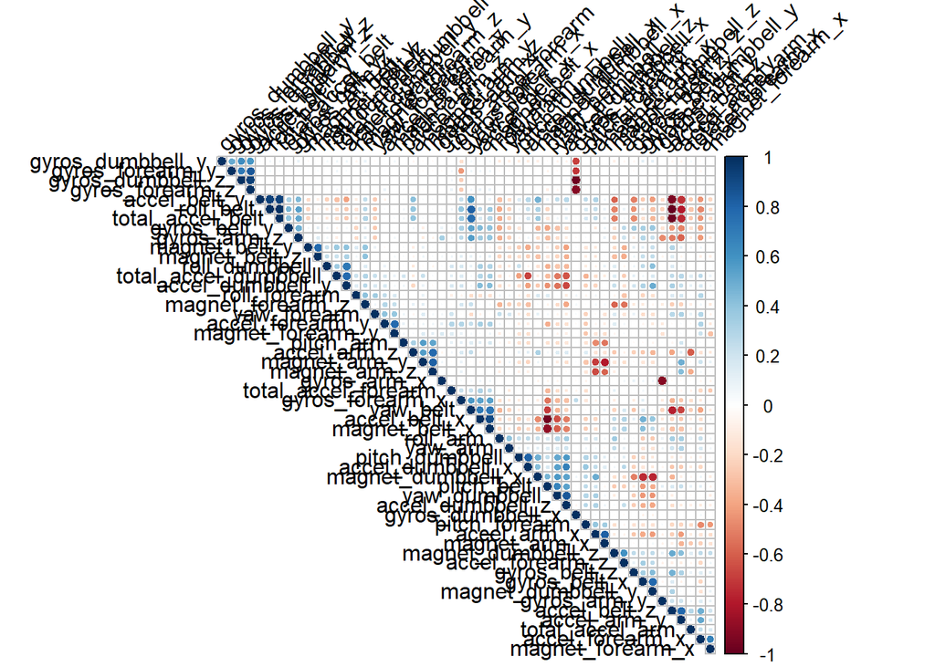

```r
# correlations

c=cor(trainingn[,-c(1,54)])
#c
#rcorr(as.matrix(trainingn[,-c(1,54)])) #we can see that we have a small number of insignificant probabilities

corrplot(c, type = "upper", order = "hclust",
         tl.col = "black", tl.srt = 45)
```

```r
#create data for cross validation

set.seed(123456)
training = data.frame(trainingn)
inTrain <- createDataPartition(training$classe, p=0.70, list=F)
train <- training[inTrain, ]
cross_validation <- training[-inTrain, ]
```

##Prediction models

```r
#Decisional trees


modFit1=train(classe~.,method="rpart",data=train)
print(modFit1$finalModel)
```

```
## n= 13737
##
## node), split, n, loss, yval, (yprob)
##       * denotes terminal node
##
##  1) root 13737 9831 A (0.28 0.19 0.17 0.16 0.18)
##    2) roll_belt< 130.5 12584 8686 A (0.31 0.21 0.19 0.18 0.11)
##      4) pitch_forearm< -33.95 1090    4 A (1 0.0037 0 0 0) *
##      5) pitch_forearm>=-33.95 11494 8682 A (0.24 0.23 0.21 0.2 0.12)
##       10) magnet_dumbbell_y< 426.5 9607 6880 A (0.28 0.18 0.24 0.19 0.11)
##         20) roll_forearm< 123.5 5961 3517 A (0.41 0.18 0.18 0.17 0.058) *
##         21) roll_forearm>=123.5 3646 2430 C (0.078 0.18 0.33 0.22 0.19) *
##       11) magnet_dumbbell_y>=426.5 1887  955 B (0.045 0.49 0.042 0.23 0.19) *
##    3) roll_belt>=130.5 1153    8 E (0.0069 0 0 0 0.99) *
```

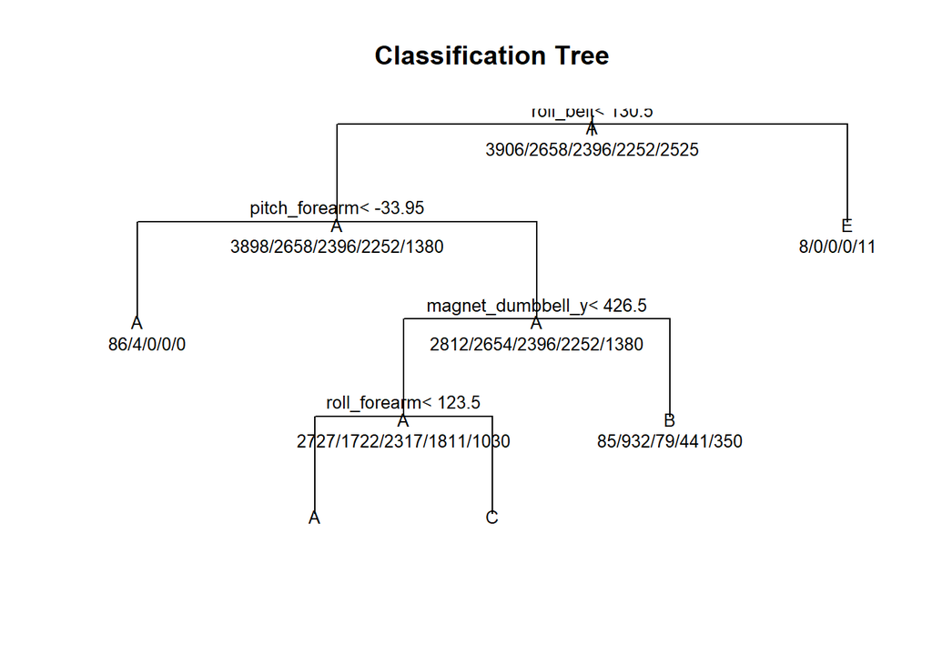

```r
#plot the tree
plot(modFit1$finalModel, uniform=TRUE, main="Classification Tree")
text(modFit1$finalModel, use.n=TRUE, all=TRUE, cex=.8)
```

[figure not shown]

```r
fancyRpartPlot(modFit1$finalModel)
```

```r
#Confusion Matrix
confusionMatrix(predict(modFit1,newdata=cross_validation), cross_validation$classe) #using cross_validation data
```

```
## Confusion Matrix and Statistics
##
##           Reference
## Prediction    A    B    C    D    E
##          A 1517  456  468  429  152
##          B   38  416   50  175  180
##          C  113  267  508  360  264
##          D    0    0    0    0    0
##          E    6    0    0    0  486
##
## Overall Statistics
##
##                Accuracy : 0.4974
##                  95% CI : (0.4845, 0.5102)
##     No Information Rate : 0.2845
##     P-Value [Acc > NIR] : < 2.2e-16
##
##                   Kappa : 0.3434
##
##  Mcnemar's Test P-Value : NA
##
## Statistics by Class:
##
##                      Class: A Class: B Class: C Class: D Class: E
## Sensitivity            0.9062  0.36523  0.49513   0.0000  0.44917
## Specificity            0.6426  0.90666  0.79337   1.0000  0.99875
## Pos Pred Value         0.5020  0.48428  0.33598      NaN  0.98780
## Neg Pred Value         0.9452  0.85615  0.88155   0.8362  0.88949
## Prevalence             0.2845  0.19354  0.17434   0.1638  0.18386
## Detection Rate         0.2578  0.07069  0.08632   0.0000  0.08258
## Detection Prevalence   0.5135  0.14596  0.25692   0.0000  0.08360
## Balanced Accuracy      0.7744  0.63595  0.64425   0.5000  0.72396
```

```r
#Values predicted for testing data
predict(modFit1,newdata=testing)
```

```
##  [1] C A C A A C C A A A C C C A C A A A A C
## Levels: A B C D E
```

```r
### Random forest

modFit<-randomForest(classe~., data=train,ntree=200)
varImp(modFit)# importance of variables
```

|  | Overall |
| --- | --- |
| num_window | 965.82489 |
| roll_belt | 838.38421 |
| pitch_belt | 441.29402 |
| yaw_belt | 564.56344 |
| total_accel_belt | 140.85784 |
| gyros_belt_x | 59.54466 |
| gyros_belt_y | 70.63266 |
| gyros_belt_z | 178.91950 |
| accel_belt_x | 83.48096 |
| accel_belt_y | 88.97697 |

[output cut: 43 more lines]

```r
#Confusion Matrix
confusionMatrix(predict(modFit,newdata=cross_validation), cross_validation$classe) #using cross_validation data
```

```
## Confusion Matrix and Statistics
##
##           Reference
## Prediction    A    B    C    D    E
##          A 1674    5    0    0    0
##          B    0 1134    8    0    0
##          C    0    0 1018    5    0
##          D    0    0    0  959    0
##          E    0    0    0    0 1082
##
## Overall Statistics
##
##                Accuracy : 0.9969
##                  95% CI : (0.9952, 0.9982)
##     No Information Rate : 0.2845
##     P-Value [Acc > NIR] : < 2.2e-16
##
##                   Kappa : 0.9961
##
##  Mcnemar's Test P-Value : NA
##
## Statistics by Class:
##
##                      Class: A Class: B Class: C Class: D Class: E
## Sensitivity            1.0000   0.9956   0.9922   0.9948   1.0000
## Specificity            0.9988   0.9983   0.9990   1.0000   1.0000
## Pos Pred Value         0.9970   0.9930   0.9951   1.0000   1.0000
## Neg Pred Value         1.0000   0.9989   0.9984   0.9990   1.0000
## Prevalence             0.2845   0.1935   0.1743   0.1638   0.1839
## Detection Rate         0.2845   0.1927   0.1730   0.1630   0.1839
## Detection Prevalence   0.2853   0.1941   0.1738   0.1630   0.1839
## Balanced Accuracy      0.9994   0.9970   0.9956   0.9974   1.0000
```

```r
#Values predicted for testing data
predict(modFit,newdata=testing)
```

```
##  1  2  3  4  5  6  7  8  9 10 11 12 13 14 15 16 17 18 19 20
##  B  A  B  A  A  E  D  B  A  A  B  C  B  A  E  E  A  B  B  B
## Levels: A B C D E
```

```r
### Boosted trees


modFit <- train(classe ~ ., method="gbm", data=train,trControl=trainControl(method = "repeatedcv", number = 5, repeats = 1),verbose=FALSE)
#Confusion Matrix
confusionMatrix(predict(modFit,newdata=cross_validation), cross_validation$classe) #using cross_validation data
```

```
## Confusion Matrix and Statistics
##
##           Reference
## Prediction    A    B    C    D    E
##          A 1666   19    0    0    0
##          B    7 1115   14    1    4
##          C    0    4 1007   15    2
##          D    1    1    5  947    5
##          E    0    0    0    1 1071
##
## Overall Statistics
##
##                Accuracy : 0.9866
##                  95% CI : (0.9833, 0.9894)
##     No Information Rate : 0.2845
##     P-Value [Acc > NIR] : < 2.2e-16
##
##                   Kappa : 0.983
##
##  Mcnemar's Test P-Value : NA
##
## Statistics by Class:
##
##                      Class: A Class: B Class: C Class: D Class: E
## Sensitivity            0.9952   0.9789   0.9815   0.9824   0.9898
## Specificity            0.9955   0.9945   0.9957   0.9976   0.9998
## Pos Pred Value         0.9887   0.9772   0.9796   0.9875   0.9991
## Neg Pred Value         0.9981   0.9949   0.9961   0.9965   0.9977
## Prevalence             0.2845   0.1935   0.1743   0.1638   0.1839
## Detection Rate         0.2831   0.1895   0.1711   0.1609   0.1820
## Detection Prevalence   0.2863   0.1939   0.1747   0.1630   0.1822
## Balanced Accuracy      0.9954   0.9867   0.9886   0.9900   0.9948
```

```r
#Values predicted for testing data
predict(modFit,newdata=testing)
```

```
##  [1] B A B A A E D B A A B C B A E E A B B B
## Levels: A B C D E
```